# Module 6: Pseudotime Trajectory Analysis

Single Cell Workshop

2026-04-24

## 1 Introduction

In Module 5 we annotated each query cell with a continuous score on every reference phenotype. Those scores already *hint* at a foetal→adult gradient within cardiomyocytes — recall the age-group scores climbing smoothly from `fetal` to `old`. Module 6 turns that hint into a single scalar per cell: **pseudotime**.

Pseudotime is a real number per cell such that cells that are close in the underlying biological process have close values. It is not real time, and the absolute scale is not identified — it is an *ordering*. Direction (which end is “early”) is a separate question, and for principal-curve methods like slingshot it has to be supplied externally. This is exactly where the Φ-Space age-group scores earn their keep: the cluster with the highest mean `fetal` score is an obvious anchor for the start of the cardiomyocyte maturation trajectory.

### 1.1 Two methods, two embeddings, two clusterings

We run two families of trajectory method:

- **Slingshot** — a *principal-curve* method. Cluster cells, build a minimum spanning tree on the cluster centroids, fit a smooth curve through each lineage, project every cell onto the curve. Pseudotime = arc length.
- **DPT (diffusion pseudotime) via destiny** — a *diffusion / random walk* method. Build a Gaussian-kernel affinity graph, eigendecompose the associated Markov chain, and use accumulated transition probability from a root as pseudotime.

Each method runs on two embeddings — **Φ-Space scores** and **PCA of expression**. Crossing method with embedding separates a *method effect* from an *embedding effect*.

Slingshot additionally depends on the **clustering** passed in: the MST is built on cluster centroids, so the clustering you choose is a first-class modelling choice, not a preprocessing detail. We therefore run slingshot **twice** per embedding — once with unsupervised Louvain clusters on PCA, once with the PhiCellType labels from Module 5 — to show how much the clustering moves the trajectory.

This gives six pseudotimes in total:

- Slingshot — 2 embeddings × 2 clusterings = 4 runs (`pt_sling_phi_unsup`, `pt_sling_pca_unsup`, `pt_sling_phi_phict`, `pt_sling_pca_phict`).
- DPT — 2 embeddings × 1 run each = 2 runs (`pt_dpt_phi`, `pt_dpt_pca`).

The four slingshot runs are used in a clustering-sensitivity figure; the canonical four-way comparison at the end of the module uses the two PhiCellType-clustered slingshot runs plus the two DPT runs.

Both methods can auto-detect endpoints if you omit the relevant argument (slingshot infers `start.clus`/`end.clus` from the MST; destiny infers `tips` from the diffusion-map geometry). We pin the root explicitly in all runs — to the highest-`fetal`-score cluster / cell — so that the pseudotimes are directly comparable.

### 1.2 Learning objectives

By the end of this module you will be able to:

- Explain what pseudotime is, what it is not, and why it needs an external directionality anchor for principal-curve methods.
- Fit slingshot and DPT trajectories on two different embeddings (PCA and Φ-Space) and separate embedding effects from method effects.
- Visualise pseudotime and principal curves on a shared UMAP.
- Use a four-pseudotime correlation matrix as a sanity check on any single trajectory result.
- Save a pseudotime-annotated CM subset for Module 7.

## 2 Load Libraries and Module 5 Output

```r
library(SingleCellExperiment)
library(slingshot)
library(destiny)
library(scater)
library(ggplot2)
library(dplyr)
library(tibble)
library(patchwork)
library(RColorBrewer)
```

The handoff from Module 5 is a single file — the query SCE with PhiSpace scores in `reducedDim`, scran logcounts in `assay(query, "logcounts")`, and per-cell annotations (`PhiCellType`, `PhiCellTypeBroad`, `PhiAge`, `group`, etc.) in `colData`.

```r
query <- readRDS("../results/05_phispace_query.rds")

cat("Assays:      ", paste(assayNames(query), collapse = ", "), "\n")
```

```
## Assays:       counts, logcounts
```

```r
cat("reducedDims: ", paste(reducedDimNames(query), collapse = ", "), "\n")
```

```
## reducedDims:  PhiSpace
```

```r
cat("Cells:       ", ncol(query), "\n")
```

```
## Cells:        10000
```

```r
cat("Broad types: ", paste(sort(unique(query$PhiCellTypeBroad)),
                            collapse = ", "), "\n")
```

```
## Broad types:  Adipocyte, Cardiomyocyte, Endocardial, Endothelial, Epicardial, Fibroblast, LEC, Lymphoid, Mast, Myeloid, Neuronal, Pericyte, vSMC
```

```r
results_dir <- "../results"
dir.create(results_dir, showWarnings = FALSE, recursive = TRUE)
```

## 3 Subset to Cardiomyocytes

Cardiomyocytes carry the foetal→adult maturation signal we want to trace. Fibroblasts and the other lineages are interesting but secondary; running pseudotime on the whole query would mix several biological processes into one trajectory.

```r
cm <- query[, query$PhiCellTypeBroad == "Cardiomyocyte"]
cat("Cardiomyocytes:", ncol(cm), "\n")
```

```
## Cardiomyocytes: 5411
```

```r
print(table(cm$group))
```

```
##
## adult fetal young
##   409  4016   986
```

```r
print(sort(table(cm$PhiCellType), decreasing = TRUE))
```

```
##
##  Cardiomyocyte:Fetal_enriched_metabolic                     Cardiomyocyte:Other
##                                    1557                                    1375
##                 Cardiomyocyte:Metabolic Cardiomyocyte:Fetal_enriched_conduction
##                                    1116                                     652
##          Cardiomyocyte:DCM_HCM_enriched              Cardiomyocyte:Inflammatory
##                                     439                                     211
##                  Cardiomyocyte:Stressed
##                                      61
```

## 4 Expression-Based Embedding: PCA on scran logcounts

For the “classical” slingshot run we need an embedding of gene expression. We compute a standard HVG → PCA pipeline on the scran logcounts we already have from Module 5.

```r
pca_cache <- file.path(results_dir, "06_cm_pca.rds")

if (file.exists(pca_cache)) {
    cm <- readRDS(pca_cache)
    message("Loaded cached CM object with PCA from ", pca_cache)
} else {
    # Highly variable gene selection
    gene_var <- rowVars(as.matrix(logcounts(cm)))
    names(gene_var) <- rownames(cm)
    n_hvg <- min(2000, nrow(cm))
    hvg <- names(sort(gene_var, decreasing = TRUE))[seq_len(n_hvg)]

    pca <- prcomp(t(as.matrix(logcounts(cm)[hvg, ])),
                  center = TRUE, scale. = FALSE)
    reducedDim(cm, "PCA") <- pca$x[, 1:20]
    saveRDS(cm, pca_cache)
}

cat("PCA dims:      ", paste(dim(reducedDim(cm, "PCA")), collapse = " x "), "\n")
```

```
## PCA dims:       5411 x 20
```

```r
cat("PhiSpace dims: ", paste(dim(reducedDim(cm, "PhiSpace")),
                             collapse = " x "), "\n")
```

```
## PhiSpace dims:  5411 x 28
```

We keep 20 PCs. That is a defensible default for single-cell data of this size; tunePhiSpace-style cross-validation of the component count is possible but not the point here.

## 5 UMAP for Visualisation

We compute a single UMAP on the PCA embedding for visualisation. All four pseudotimes end up displayed on this same layout, which makes cross-method comparison a matter of eyeballing the same regions of the same plot. `n_neighbors = 15` and `min_dist = 0.5` were picked from the parameter sweep in `scripts/06_umap_param_sweep.R` — low `n_neighbors` values fragmented the cardiomyocyte continuum into islands that had no biological meaning.

None of the pseudotime methods below take UMAP as input; the layout is strictly for plotting.

```r
umap_cache <- file.path(results_dir, "06_cm_umap.rds")

if (file.exists(umap_cache)) {
    reducedDim(cm, "UMAP") <- readRDS(umap_cache)
    message("Loaded cached UMAP")
} else {
    set.seed(42)
    cm <- scater::runUMAP(cm, dimred = "PCA", name = "UMAP",
                          n_neighbors = 15, min_dist = 0.5)
    saveRDS(reducedDim(cm, "UMAP"), umap_cache)
}
```

### 5.1 Sanity check: does the UMAP make biological sense?

Four panels before we run any trajectory fitting:

1. **Donor stage** (`group`) — we expect a smooth foetal → adult gradient if the embedding captures the maturation axis.
2. **Fetal score** — the Φ-Space `fetal` coordinate on its own. Blue → white; the bluer a cell, the more fetal. This is also what we use to pick the slingshot anchor cluster.
3. **Φ-Space pseudotime**, defined as `adult − fetal` on the reference age-group scores. The Gao 2026 reference has four age bins (`fetal`, `young`, `middle`, `old`); we take the adult score as the mean of the three post-natal bins. Their difference is a per-cell scalar that is already an ordering along the maturation axis — no trajectory model needed.
4. **Φ-Space pseudotime (rescaled)** — the same score passed through a sign-preserving cube-root transform (`sign(x) · |x|^(1/3)`). The raw `adult − fetal` is heavy-tailed and the colour gradient gets dominated by a handful of extreme cells; cube-root compresses the tails without flipping any orderings.

The Φ-Space pseudotime (panels 3 and 4) is a useful anchor for the rest of the module. It is the “trivially defined” pseudotime that slingshot and DPT will be compared against. If none of the fitted pseudotimes reproduce this gradient, something has gone wrong.

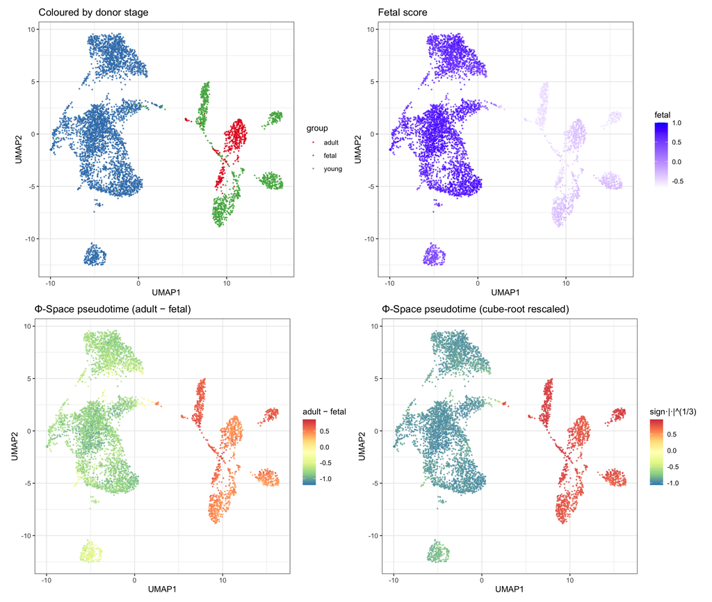

```r
umap_df0 <- as.data.frame(reducedDim(cm, "UMAP"))
colnames(umap_df0) <- c("UMAP1", "UMAP2")

# Φ-Space pseudotime: adult-vs-fetal contrast on the reference
# age-group scores. "adult" = mean of the three post-natal bins.
phi_scores_all <- reducedDim(cm, "PhiSpace")
adult_score    <- rowMeans(phi_scores_all[, c("young", "middle", "old")])
cm$pt_phi_score    <- adult_score - phi_scores_all[, "fetal"]
cm$pt_phi_score_cr <- sign(cm$pt_phi_score) * abs(cm$pt_phi_score)^(1/3)
cm$fetal_score     <- phi_scores_all[, "fetal"]

base_umap <- function(df, colour_col) {
    ggplot(df, aes(UMAP1, UMAP2, colour = .data[[colour_col]])) +
        geom_point(size = 0.4, alpha = 0.7) +
        theme_bw(base_size = 11) +
        theme(aspect.ratio = 1)
}

p_by_group <- base_umap(
    cbind(umap_df0, group = cm$group), "group"
) +
    scale_colour_brewer(palette = "Set1") +
    labs(title = "Coloured by donor stage", colour = "group")

p_by_fetal <- base_umap(
    cbind(umap_df0, fetal = cm$fetal_score), "fetal"
) +
    scale_colour_gradient(low = "white", high = "blue") +
    labs(title = "Fetal score", colour = "fetal")

p_by_phi_pt <- base_umap(
    cbind(umap_df0, pt = cm$pt_phi_score), "pt"
) +
    scale_colour_distiller(palette = "Spectral") +
    labs(title = "Φ-Space pseudotime (adult − fetal)",
         colour = "adult − fetal")

p_by_phi_pt_cr <- base_umap(
    cbind(umap_df0, pt_cr = cm$pt_phi_score_cr), "pt_cr"
) +
    scale_colour_distiller(palette = "Spectral") +
    labs(title = "Φ-Space pseudotime (cube-root rescaled)",
         colour = "sign·|·|^(1/3)")

(p_by_group | p_by_fetal) / (p_by_phi_pt | p_by_phi_pt_cr)
```

## 6 Unsupervised Clustering

Slingshot (and monocle) are *clustering-based* trajectory methods: they build a minimum spanning tree on cluster centroids and fit principal curves through the MST. Your clustering is not a preprocessing detail but a first-class modelling choice — two different clusterings of the same cells can give two different backbone topologies and, in turn, two different pseudotimes. This is arguably the biggest practical drawback of principal-curve methods, and one reason diffusion-based methods (DPT below) are useful as a cross-check.

We compute a standard unsupervised clustering — SNN graph on the PCA embedding, Louvain communities — and use *that* as the slingshot input. Using the unsupervised clusters rather than PhiCellType means the slingshot fit is not directly circular with the Φ-Space anchoring (the start cluster is still chosen via the Φ-Space `fetal` score, but the cluster definitions themselves are reference-free).

```r
cluster_cache <- file.path(results_dir, "06_cm_clusters.rds")

if (file.exists(cluster_cache)) {
    cm$cluster <- readRDS(cluster_cache)
    message("Loaded cached clusters")
} else {
    set.seed(42)
    snn <- scran::buildSNNGraph(cm, use.dimred = "PCA", k = 20)
    cm$cluster <- factor(igraph::cluster_louvain(snn)$membership)
    saveRDS(cm$cluster, cluster_cache)
}

cat("Cluster sizes:\n")
```

```
## Cluster sizes:
```

```r
print(table(cm$cluster))
```

```
##
##    1    2    3    4    5    6    7    8    9   10   11   12
## 1121  217  790  303  309  216 1144  215  211  465  310  110
```

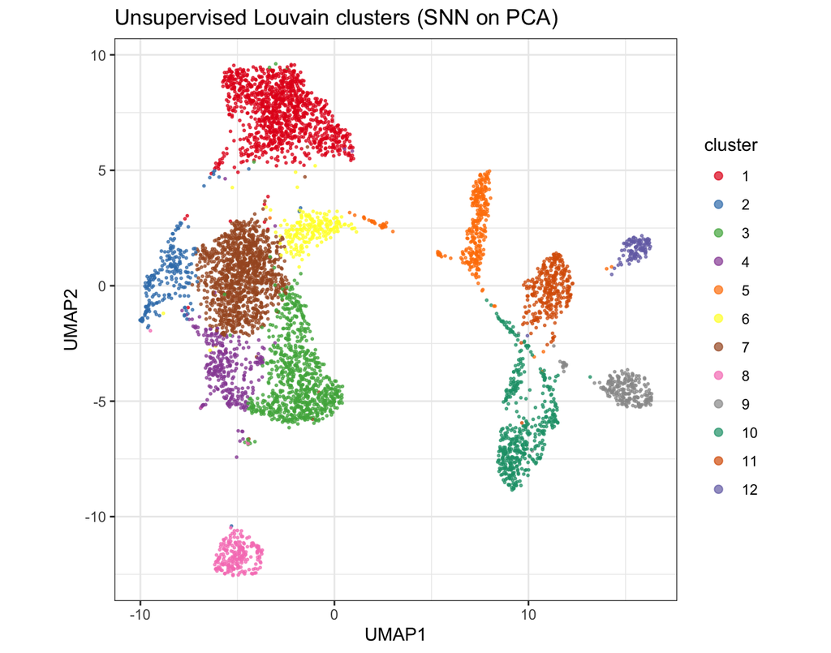

```r
clust_levels <- levels(cm$cluster)
clust_pool <- c(brewer.pal(9, "Set1"),
                brewer.pal(8, "Dark2"),
                brewer.pal(8, "Set2"))
clust_pal <- clust_pool[seq_along(clust_levels)]
names(clust_pal) <- clust_levels

ggplot(
    cbind(umap_df0, cluster = cm$cluster),
    aes(UMAP1, UMAP2, colour = cluster)
) +
    geom_point(size = 0.4, alpha = 0.7) +
    scale_colour_manual(values = clust_pal) +
    theme_bw(base_size = 11) +
    theme(aspect.ratio = 1) +
    guides(colour = guide_legend(override.aes = list(size = 2))) +
    labs(title = "Unsupervised Louvain clusters (SNN on PCA)")
```

## 7 Picking the Trajectory Anchors

For each slingshot run we need a `start.clus`. We pick the cluster whose mean score on the reference `fetal` phenotype is highest — Φ-Space chooses the direction, the clustering defines the units. Since we are running slingshot with two different clusterings, we need two anchors.

```r
phi_scores  <- reducedDim(cm, "PhiSpace")
fetal_score <- phi_scores[, "fetal"]

mean_fetal_by <- function(cluster_vec) {
    tibble(cluster = cluster_vec, fetal = fetal_score) |>
        group_by(cluster) |>
        summarise(mean_fetal = mean(fetal), n = n(),
                  .groups = "drop") |>
        arrange(desc(mean_fetal))
}

anchor_unsup_tbl <- mean_fetal_by(cm$cluster)
anchor_phict_tbl <- mean_fetal_by(cm$PhiCellType)

cat("Anchor table — unsupervised clusters:\n")
```

```
## Anchor table — unsupervised clusters:
```

```r
print(anchor_unsup_tbl)
```

```
## # A tibble: 12 × 3
##    cluster mean_fetal     n
##    <fct>        <dbl> <int>
##  1 7            0.721  1144
##  2 3            0.699   790
##  3 6            0.678   216
##  4 2            0.665   217
##  5 1            0.634  1121
##  6 4            0.629   303
##  7 8            0.435   215
##  8 9           -0.342   211
##  9 11          -0.362   310
## 10 10          -0.368   465
## 11 5           -0.470   309
## 12 12          -0.520   110
```

```r
cat("\nAnchor table — PhiCellType:\n")
```

```
##
## Anchor table — PhiCellType:
```

```r
print(anchor_phict_tbl)
```

```
## # A tibble: 7 × 3
##   cluster                                 mean_fetal     n
##   <chr>                                        <dbl> <int>
## 1 Cardiomyocyte:Other                          0.667  1375
## 2 Cardiomyocyte:Metabolic                      0.665  1116
## 3 Cardiomyocyte:Fetal_enriched_metabolic       0.578  1557
## 4 Cardiomyocyte:Stressed                       0.554    61
## 5 Cardiomyocyte:Fetal_enriched_conduction     -0.326   652
## 6 Cardiomyocyte:Inflammatory                  -0.404   211
## 7 Cardiomyocyte:DCM_HCM_enriched              -0.432   439
```

```r
start_cluster_unsup <- as.character(anchor_unsup_tbl$cluster[1])
start_cluster_phict <- as.character(anchor_phict_tbl$cluster[1])

cat("\nstart.clus (unsupervised): ", start_cluster_unsup, "\n", sep = "")
```

```
##
## start.clus (unsupervised): 7
```

```r
cat("start.clus (PhiCellType):  ",  start_cluster_phict, "\n", sep = "")
```

```
## start.clus (PhiCellType):  Cardiomyocyte:Other
```

For destiny we need a single cell, not a cluster. We decouple this choice from any clustering and just pick the globally most fetal cell, so that the two DPT runs don’t depend on which Louvain partition we happened to compute.

```r
root_cell <- which.max(fetal_score)
cat("Root cell index:", root_cell,
    " (fetal score =", round(fetal_score[root_cell], 3), ")\n")
```

```
## Root cell index: 1800  (fetal score = 1 )
```

## 8 Slingshot: four runs

Two embeddings × two clusterings. The same `dist.method = "simple"` is used throughout — the default (scaled Mahalanobis) is singular when small PhiCellType subclusters push the within-cluster covariance below the inversion threshold.

```r
run_slingshot <- function(cache, dimred, clusters, start) {
    fp <- file.path(results_dir, cache)
    if (file.exists(fp)) {
        message("Loaded cached ", cache)
        return(readRDS(fp))
    }
    sds <- slingshot(
        reducedDim(cm, dimred),
        clusterLabels = clusters,
        start.clus    = start,
        dist.method   = "simple"
    )
    saveRDS(sds, fp)
    sds
}

sling_phi_unsup <- run_slingshot("06_slingshot_phi_unsup.rds",
                                 "PhiSpace", cm$cluster,
                                 start_cluster_unsup)
sling_pca_unsup <- run_slingshot("06_slingshot_pca_unsup.rds",
                                 "PCA",      cm$cluster,
                                 start_cluster_unsup)
sling_phi_phict <- run_slingshot("06_slingshot_phi_phict.rds",
                                 "PhiSpace", cm$PhiCellType,
                                 start_cluster_phict)
sling_pca_phict <- run_slingshot("06_slingshot_pca_phict.rds",
                                 "PCA",      cm$PhiCellType,
                                 start_cluster_phict)
```

Slingshot’s `slingPseudotime()` returns one column per lineage; for a predominantly linear CM maturation trajectory we expect one dominant lineage. We average over lineages to get a single pseudotime per cell.

```r
lineage_pt <- function(sds) rowMeans(slingPseudotime(sds), na.rm = TRUE)

cm$pt_sling_phi_unsup <- lineage_pt(sling_phi_unsup)
cm$pt_sling_pca_unsup <- lineage_pt(sling_pca_unsup)
cm$pt_sling_phi_phict <- lineage_pt(sling_phi_phict)
cm$pt_sling_pca_phict <- lineage_pt(sling_pca_phict)

cat("Lineages found per run:\n")
```

```
## Lineages found per run:
```

```r
cat("  PhiSpace / unsupervised: ", length(slingLineages(sling_phi_unsup)), "\n")
```

```
##   PhiSpace / unsupervised:  6
```

```r
cat("  PCA      / unsupervised: ", length(slingLineages(sling_pca_unsup)), "\n")
```

```
##   PCA      / unsupervised:  7
```

```r
cat("  PhiSpace / PhiCellType:  ", length(slingLineages(sling_phi_phict)), "\n")
```

```
##   PhiSpace / PhiCellType:   2
```

```r
cat("  PCA      / PhiCellType:  ", length(slingLineages(sling_pca_phict)), "\n")
```

```
##   PCA      / PhiCellType:   3
```

## 9 DPT via destiny

For the diffusion branch of the 2 × 2 grid we build a diffusion map on each embedding and compute DPT from the same root cell we pinned above.

### 9.1 DPT on PCA

```r
dpt_cache <- file.path(results_dir, "06_dpt_pca.rds")

if (file.exists(dpt_cache)) {
    dpt <- readRDS(dpt_cache)
    message("Loaded cached DPT/PCA result")
} else {
    dm  <- DiffusionMap(as.matrix(reducedDim(cm, "PCA")),
                        n_eigs = 20, sigma = "local", verbose = FALSE)
    dpt <- DPT(dm, tips = root_cell)
    saveRDS(dpt, dpt_cache)
}

cm$pt_dpt_pca <- dpt$dpt
summary(cm$pt_dpt_pca)
```

```
##    Min. 1st Qu.  Median    Mean 3rd Qu.    Max.
##  0.0000  0.4120  0.6941  5.4210 16.1667 20.6281
```

### 9.2 DPT on Φ-Space

Identical settings to the PCA run — same `n_eigs`, same `sigma`, same root — so the two DPT pseudotimes differ in exactly one thing: the input embedding.

```r
dpt_phi_cache <- file.path(results_dir, "06_dpt_phispace.rds")

if (file.exists(dpt_phi_cache)) {
    dpt_phi <- readRDS(dpt_phi_cache)
    message("Loaded cached DPT/PhiSpace result")
} else {
    dm_phi <- DiffusionMap(as.matrix(reducedDim(cm, "PhiSpace")),
                           n_eigs = 20, sigma = "local",
                           verbose = FALSE)
    dpt_phi <- DPT(dm_phi, tips = root_cell)
    saveRDS(dpt_phi, dpt_phi_cache)
}

cm$pt_dpt_phi <- dpt_phi$dpt
summary(cm$pt_dpt_phi)
```

```
##    Min. 1st Qu.  Median    Mean 3rd Qu.    Max.
##  0.0000  0.3599  0.5007  4.8707 16.3791 19.1739
```

Calling `DPT(dm)` with no `tips` would have let destiny auto-detect trajectory endpoints from the diffusion-map geometry. We pass the root explicitly here to keep destiny’s pseudotime directly comparable with the slingshot runs (which also received an explicit `start.clus`).

## 10 Visualising Pseudotimes on UMAP

We colour cells by pseudotime using the `Spectral` ColorBrewer palette (blue for low values, red for high) — an ordered diverging scale whose two endpoints are visually distinct, unlike sequential palettes like viridis. Every panel sits on the shared UMAP computed above; for slingshot panels we overlay the principal curves using `slingshot::embedCurves()`, which re-fits the curves in UMAP space given the existing cell ordering.

```r
rescale01 <- function(x) {
    x <- x - min(x, na.rm = TRUE)
    x / max(x, na.rm = TRUE)
}

cm$pt_sling_phi_unsup_01 <- rescale01(cm$pt_sling_phi_unsup)
cm$pt_sling_pca_unsup_01 <- rescale01(cm$pt_sling_pca_unsup)
cm$pt_sling_phi_phict_01 <- rescale01(cm$pt_sling_phi_phict)
cm$pt_sling_pca_phict_01 <- rescale01(cm$pt_sling_pca_phict)
cm$pt_dpt_phi_01         <- rescale01(cm$pt_dpt_phi)
cm$pt_dpt_pca_01         <- rescale01(cm$pt_dpt_pca)
```

```r
umap_df <- as.data.frame(reducedDim(cm, "UMAP"))
colnames(umap_df) <- c("UMAP1", "UMAP2")

# Embed slingshot curves from their native embeddings into the shared UMAP.
embed_curves_df <- function(sds, label) {
    sds_u  <- embedCurves(sds, reducedDim(cm, "UMAP"))
    curves <- slingCurves(sds_u)
    do.call(rbind, lapply(seq_along(curves), function(i) {
        crv <- curves[[i]]
        s   <- crv$s[crv$ord, , drop = FALSE]
        data.frame(UMAP1 = s[, 1], UMAP2 = s[, 2],
                   lineage = paste0(label, "_L", i))
    }))
}

curves_phi_unsup_df <- embed_curves_df(sling_phi_unsup, "phi_unsup")
curves_pca_unsup_df <- embed_curves_df(sling_pca_unsup, "pca_unsup")
curves_phi_phict_df <- embed_curves_df(sling_phi_phict, "phi_phict")
curves_pca_phict_df <- embed_curves_df(sling_pca_phict, "pca_phict")

pt_scale <- scale_colour_distiller(
    palette = "Spectral",
    name    = "Pseudotime"
)

umap_base <- function(pt_vec) {
    df <- cbind(umap_df, pt = pt_vec)
    ggplot(df, aes(UMAP1, UMAP2, colour = pt)) +
        geom_point(size = 0.4, alpha = 0.7) +
        pt_scale +
        theme_bw(base_size = 11) +
        theme(aspect.ratio = 1)
}

with_curves <- function(p, crv_df) {
    p + geom_path(data = crv_df,
                  aes(UMAP1, UMAP2, group = lineage),
                  inherit.aes = FALSE,
                  colour = "lightgray", linewidth = 0.8)
}
```

### 10.1 Slingshot clustering sensitivity

The same slingshot call, run four times — two embeddings × two clusterings. If the four panels paint different gradients on the same UMAP, the clustering choice is not a preprocessing detail.

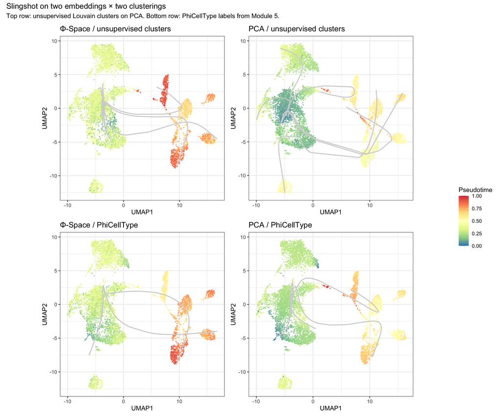

```r
p_phi_unsup <- with_curves(umap_base(cm$pt_sling_phi_unsup_01),
                           curves_phi_unsup_df) +
    labs(title = "Φ-Space / unsupervised clusters")
p_pca_unsup <- with_curves(umap_base(cm$pt_sling_pca_unsup_01),
                           curves_pca_unsup_df) +
    labs(title = "PCA / unsupervised clusters")
p_phi_phict <- with_curves(umap_base(cm$pt_sling_phi_phict_01),
                           curves_phi_phict_df) +
    labs(title = "Φ-Space / PhiCellType")
p_pca_phict <- with_curves(umap_base(cm$pt_sling_pca_phict_01),
                           curves_pca_phict_df) +
    labs(title = "PCA / PhiCellType")

(p_phi_unsup | p_pca_unsup) / (p_phi_phict | p_pca_phict) +
    plot_layout(guides = "collect") +
    plot_annotation(
        title    = "Slingshot on two embeddings × two clusterings",
        subtitle = "Top row: unsupervised Louvain clusters on PCA. Bottom row: PhiCellType labels from Module 5."
    )
```

Reading the figure:

- **Top row vs bottom row** (clustering effect). With unsupervised Louvain clusters the trajectory tends to follow whatever the Louvain partition happened to emphasise on the PCA graph — including axes that have little to do with maturation. Switching to PhiCellType, where the clusters are defined by the biology we care about (fetal-enriched / metabolic / stressed / …), pulls the principal curves onto the actual foetal → adult axis.
- **Left column vs right column** (embedding effect). Φ-Space tends to produce a smoother principal curve because the embedding *itself* is aligned with the reference age groups; PCA is free to detour through donor or batch structure before reaching the adult end.

For the canonical comparison with DPT below we use the **PhiCellType-clustered** slingshot runs (bottom row).

### 10.2 Canonical four-way: slingshot (PhiCellType) vs DPT

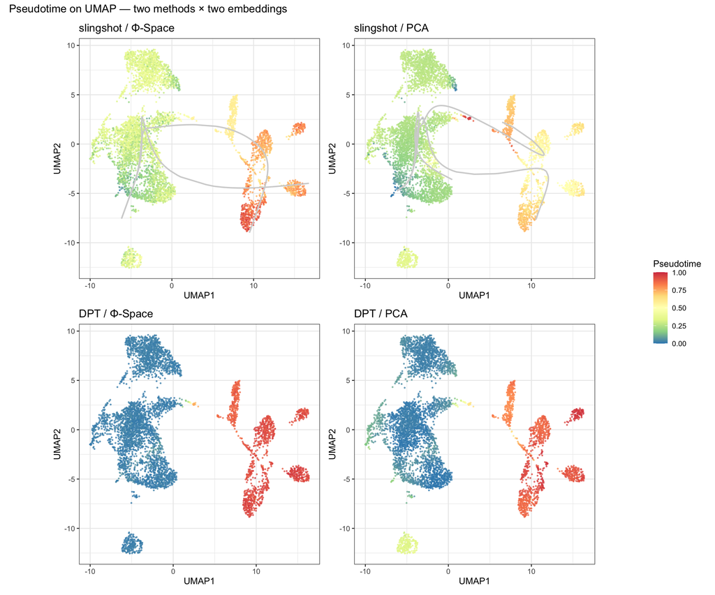

```r
p_sling_phi <- with_curves(umap_base(cm$pt_sling_phi_phict_01),
                           curves_phi_phict_df) +
    labs(title = "slingshot / Φ-Space")
p_sling_pca <- with_curves(umap_base(cm$pt_sling_pca_phict_01),
                           curves_pca_phict_df) +
    labs(title = "slingshot / PCA")
p_dpt_phi <- umap_base(cm$pt_dpt_phi_01) +
    labs(title = "DPT / Φ-Space")
p_dpt_pca <- umap_base(cm$pt_dpt_pca_01) +
    labs(title = "DPT / PCA")

(p_sling_phi | p_sling_pca) / (p_dpt_phi | p_dpt_pca) +
    plot_layout(guides = "collect") +
    plot_annotation(
        title = "Pseudotime on UMAP — two methods × two embeddings"
    )
```

If all four panels paint the same blue → red gradient across the same UMAP regions, the trajectory is robust. If the two slingshot panels agree but the two DPT panels disagree with them, that is a pure method effect; if the two Φ-Space panels agree but the two PCA panels do not, that is a pure embedding effect.

## 11 Four-Way Comparison

For the quantitative comparison we compare slingshot run with **PhiCellType clusters** — the variant that best recovered the foetal → adult axis in the sensitivity figure above — against DPT on the same two embeddings. This is the 2 × 2 grid of methods × embeddings we promised in the introduction.

```r
pt_mat <- as.data.frame(colData(cm)[,
    c("pt_sling_phi_phict_01", "pt_sling_pca_phict_01",
      "pt_dpt_phi_01",         "pt_dpt_pca_01")])
colnames(pt_mat) <- c("slingshot/PhiSpace", "slingshot/PCA",
                      "DPT/PhiSpace",       "DPT/PCA")
```

### 11.1 Correlation matrix

```r
round(cor(pt_mat, use = "complete.obs", method = "spearman"), 3)
```

```
##                    slingshot/PhiSpace slingshot/PCA DPT/PhiSpace DPT/PCA
## slingshot/PhiSpace              1.000         0.782        0.611   0.602
## slingshot/PCA                   0.782         1.000        0.601   0.742
## DPT/PhiSpace                    0.611         0.601        1.000   0.617
## DPT/PCA                         0.602         0.742        0.617   1.000
```

Spearman (rank) correlation is the right scalar summary because each method has a different absolute scale and we only care about the *order* of cells.

### 11.2 Pairs plot

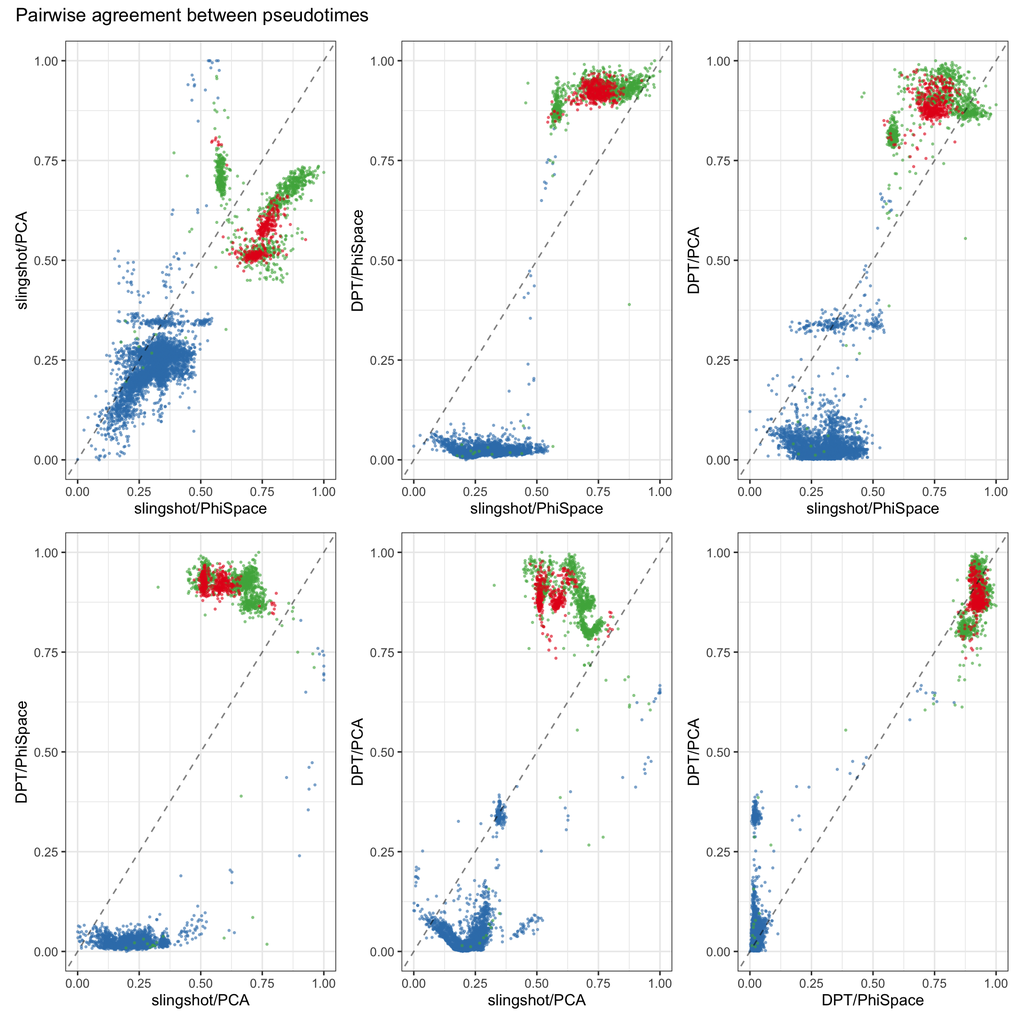

```r
pt_long <- pt_mat |>
    rownames_to_column("cell") |>
    mutate(group = cm$group[match(cell, colnames(cm))])

make_pair <- function(x, y) {
    ggplot(pt_long, aes(.data[[x]], .data[[y]], colour = group)) +
        geom_point(size = 0.4, alpha = 0.5) +
        geom_abline(slope = 1, intercept = 0,
                    linetype = "dashed", alpha = 0.5) +
        scale_colour_brewer(palette = "Set1") +
        theme_bw(base_size = 11) +
        theme(legend.position = "none") +
        labs(x = x, y = y)
}

method_names <- c("slingshot/PhiSpace", "slingshot/PCA",
                  "DPT/PhiSpace",       "DPT/PCA")
pair_idx <- combn(method_names, 2, simplify = FALSE)
pairs <- lapply(pair_idx, function(p) make_pair(p[1], p[2]))

wrap_plots(pairs, ncol = 3) +
    plot_annotation(title = "Pairwise agreement between pseudotimes")
```

Read the 2 × 2 grid of methods diagonally:

- **Rows of the method table** (slingshot/PhiSpace ↔︎ slingshot/PCA, or DPT/PhiSpace ↔︎ DPT/PCA) isolate the *embedding* effect — same method, different embedding.
- **Columns of the method table** (slingshot/PhiSpace ↔︎ DPT/PhiSpace, or slingshot/PCA ↔︎ DPT/PCA) isolate the *method* effect — same embedding, different trajectory family.
- **Anti-diagonal pairs** (slingshot/PhiSpace ↔︎ DPT/PCA, slingshot/PCA ↔︎ DPT/PhiSpace) vary both at once; agreement here is the strongest evidence the trajectory is not an artefact of either choice.

### 11.3 Pseudotime vs donor stage

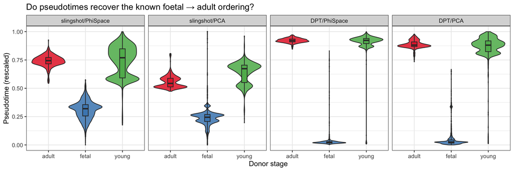

```r
box_df <- pt_long |>
    tidyr::pivot_longer(
        cols = all_of(method_names),
        names_to = "method", values_to = "pseudotime"
    ) |>
    mutate(method = factor(method, levels = method_names))

ggplot(box_df, aes(group, pseudotime, fill = group)) +
    geom_violin(scale = "width", alpha = 0.8) +
    geom_boxplot(width = 0.15, alpha = 0.6, outlier.size = 0.3) +
    scale_fill_brewer(palette = "Set1") +
    facet_wrap(~ method, nrow = 1) +
    labs(x = "Donor stage", y = "Pseudotime (rescaled)",
         fill = "Stage",
         title = "Do pseudotimes recover the known foetal → adult ordering?") +
    theme_bw(base_size = 12) +
    theme(legend.position = "none")
```

The donor stage (`group`) is held-out information: none of the four pseudotime methods saw it. If the violins step upward cleanly from `fetal` to `adult` on all four panels, the trajectory is recovering the real maturation order.

## 12 Handing Off to Module 7

```r
final_cache <- file.path(results_dir, "06_cm_pseudotime.rds")
saveRDS(cm, final_cache)
cat("Annotated CM object at", final_cache, "\n")
```

```
## Annotated CM object at ../results/06_cm_pseudotime.rds
```

The object carries, in addition to everything Module 5 handed us:

- `reducedDim(cm, "PCA")` — 20 PCs on scran logcounts of HVGs.
- `reducedDim(cm, "UMAP")` — 2D UMAP on the PCA embedding (`n_neighbors = 15`, `min_dist = 0.5`).
- `colData(cm)$cluster` — unsupervised Louvain clusters on the PCA SNN graph; used in the clustering-sensitivity slingshot runs.
- `colData(cm)$pt_phi_score` — Φ-Space pseudotime (`adult − fetal` reference score), a trajectory-free baseline.
- `colData(cm)$pt_sling_phi_unsup` / `pt_sling_pca_unsup` — slingshot with unsupervised clusters (clustering-sensitivity runs).
- `colData(cm)$pt_sling_phi_phict` / `pt_sling_pca_phict` — slingshot with PhiCellType clusters (canonical).
- `colData(cm)$pt_dpt_phi` / `pt_dpt_pca` — DPT pseudotimes from the two destiny runs.
- `colData(cm)$pt_*_01` — the same pseudotimes rescaled to `[0, 1]` for cross-method comparison.

For Module 7 we will primarily use `pt_sling_phi_phict` — the Φ-Space slingshot pseudotime with PhiCellType clusters — as the canonical time axis. The other five live in the object for optional sensitivity analyses.